# Finite differences 1

The WANT team

24/09/2018

# Learning goals

- Understand the use of Taylor series
- Understand the mathematics of Taylor series
- Be able to calculate Taylor series for arbitrary functions
- Derive approximations for first derivatives from Taylor series

# Introduction

With this markdown you are going to to analyse the effect of properties and numerical schemes on the behavior of the solutions for simple 0D (no spatial dimensions) kind of models, known as bucket or reservoir models. The differential equations that need to be solved are simple ordinary differential equations.

# Part 1

# Exercise 1.1

As the first example of a simple ordenary differential equation (ODE) an emptying reservoir is considered. It is an illustrative example because the exact solution is known so different methods can be compared to the real answer.

physical example of the emptying reservoir (or emptying bucket)

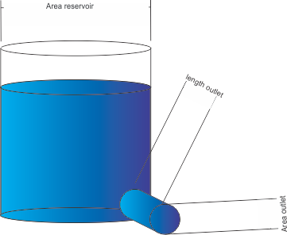

This system can be represented by the following ODE:
$$\dfrac{ds}{dt} = -\alpha s$$

The mathematical definition of the time derivate is as follows

$$\dfrac{ds}{dt} = \lim_{\Delta t\to\ 0}\frac{s(t+\Delta t)-s(t)}{\Delta t}$$

To approximate this function to implement it in a computer this function can be simplified, taking a small $\Delta$t:

$$\dfrac{ds}{dt} = \frac{s(t+\Delta t)-s(t)}{\Delta t}$$

1.1.1 Combine these function to make a discretisation for the next timestep (s(t+$\Delta$t))

$$s(t+\Delta t) = s(t)(1-\alpha \Delta t)$$

Maybe the hard track can derive the true solution here

# Exercise 1.2

To implement this function four vallues need to be given to be able to run:

```r
begin.time = 0    # usually this variable is set to 0
end.time = 50     # end time of the simulation (50)
dt = 10          # delta t; time discretisation (0.1)
init.state = 3    # state of the system at the beginning of the simulation (100)
alpha = 0.25       # decay constant (6)
```

Implement the formula derived in question 1.1 in the following script to run the first simulation

```r
sys.fun = function(state)
{
  newstate = ...
  return(newstate)
}
```

```r
sys.fun = function(state)
{
  newstate = state*(1-alpha*dt)
  return(newstate)
}
```

Run the following chunk to run and visualise the simulation

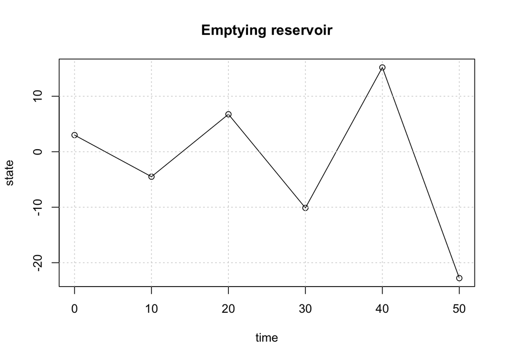

```r
time = begin.time
result.state= c(init.state)
result.time = c(time)
current.state = init.state
##time loop
while(time < end.time)
{
  current.state = sys.fun(current.state)
  result.state = c(result.state,current.state)
  time = time + dt
  result.time = c(result.time,time)
}

##plotting
plot(result.time,result.state,type='o',xlab="time",ylab="state")
title(main='Emptying reservoir')
grid()
```

1.2.1 Vary the ‘dt’ parameter between 0.01 and 25. TIP! adjust the value of dt and use the speed button ‘run all previous chunks’ in the ‘Data collection and plotting’ chunk to have a direct view of the result. Are there any numerical problems arising beyond a certain value for dt? Do you notice any time difference in run-time?

1.2.2 Reset dt to 0.5 and vary alpha in the same way. Characterise the effect of this parameter. Did it gave any numerical problems, and if so, what kind and for which value of alpha?

1.2.3 Add the following two lines of code into chunk4 just below the plot command.

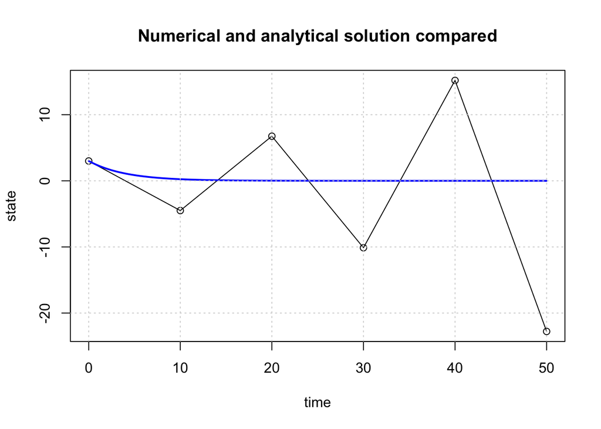

```r
time = begin.time
result.state= c(init.state)
result.time = c(time)
current.state = init.state
##time loop
while(time < end.time)
{
  current.state = sys.fun(current.state)
  result.state = c(result.state,current.state)
  time = time + dt
  result.time = c(result.time,time)
}

##plotting
plot(result.time,result.state,type='o', xlab="time",ylab="state")
time.sequence = seq(begin.time,end.time,by=0.1)
analyt.state=init.state * exp(-time.sequence*alpha)
lines(time.sequence,analyt.state,col='blue',lwd=2)
title(main='Numerical and analytical solution compared')
grid()
```

1.2.4 At which dt do the numerical approximation and analytical solution agree fairly reasonably?